# Customer_Analytics_Step1

Anagha Karanam

12/8/2018

## *Segmentation on Customer Feedback on their flight experience.*

> *Moment of truth*: IT IS REALLY DIFFICULT TO FIND A DATASET OF YOUR DREAMS!

The series of articles are a step by step guide (with findings & learnings, also with lots of issues & resolutions encountered) on SEGMENTATION based on customer feedback of their flight experiences.

Here is the dataset I used: https://www.kaggle.com/johndddddd/customer-satisfaction

### loading the data & reading it.

```r
if (!require("openxlsx")) install.packages("openxlsx")
library("openxlsx")

cs_data <- read.xlsx("customer-satisfaction/satisfaction.xlsx", sheet = 1, colNames = TRUE,rowNames = FALSE, skipEmptyRows = TRUE,
          skipEmptyCols = TRUE, na.strings = NA,fillMergedCells = FALSE)
```

> *Moment of truth*: str() function? summary() function? OPEN THE EXCEL SHEET & SCROLL TO SEE THE TRUTH ABOUT DATA. Once you do so, trust what str says.

### summary

```r
str(cs_data)
```

```
## 'data.frame':    129880 obs. of  24 variables:
##  $ id                               : num  11112 110278 103199 47462 120011 ...
##  $ satisfaction_v2                  : chr  "satisfied" "satisfied" "satisfied" "satisfied" ...
##  $ Gender                           : chr  "Female" "Male" "Female" "Female" ...
##  $ Customer.Type                    : chr  "Loyal Customer" "Loyal Customer" "Loyal Customer" "Loyal Customer" ...
##  $ Age                              : num  65 47 15 60 70 30 66 10 56 22 ...
##  $ Type.of.Travel                   : chr  "Personal Travel" "Personal Travel" "Personal Travel" "Personal Travel" ...
##  $ Class                            : chr  "Eco" "Business" "Eco" "Eco" ...
##  $ Flight.Distance                  : num  265 2464 2138 623 354 ...
##  $ Seat.comfort                     : num  0 0 0 0 0 0 0 0 0 0 ...
##  $ Departure/Arrival.time.convenient: num  0 0 0 0 0 0 0 0 0 0 ...
##  $ Food.and.drink                   : num  0 0 0 0 0 0 0 0 0 0 ...
##  $ Gate.location                    : num  2 3 3 3 3 3 3 3 3 3 ...
##  $ Inflight.wifi.service            : num  2 0 2 3 4 2 2 2 5 2 ...
##  $ Inflight.entertainment           : num  4 2 0 4 3 0 5 0 3 0 ...
##  $ Online.support                   : num  2 2 2 3 4 2 5 2 5 2 ...
##  $ Ease.of.Online.booking           : num  3 3 2 1 2 2 5 2 4 2 ...
##  $ On-board.service                 : num  3 4 3 1 2 5 5 3 4 2 ...
##  $ Leg.room.service                 : num  0 4 3 0 0 4 0 3 0 4 ...
##  $ Baggage.handling                 : num  3 4 4 1 2 5 5 4 1 5 ...
##  $ Checkin.service                  : num  5 2 4 4 4 5 5 5 5 3 ...
##  $ Cleanliness                      : num  3 3 4 1 2 4 5 4 4 4 ...
##  $ Online.boarding                  : num  2 2 2 3 5 2 3 2 4 2 ...
##  $ Departure.Delay.in.Minutes       : num  0 310 0 0 0 0 17 0 0 30 ...
##  $ Arrival.Delay.in.Minutes         : num  0 305 0 0 0 0 15 0 0 26 ...
```

### summary

```r
summary(cs_data)
```

```
##        id         satisfaction_v2       Gender          Customer.Type
##  Min.   :     1   Length:129880      Length:129880      Length:129880
##  1st Qu.: 32471   Class :character   Class :character   Class :character
##  Median : 64940   Mode  :character   Mode  :character   Mode  :character
##  Mean   : 64940
##  3rd Qu.: 97410
##  Max.   :129880
##
##       Age        Type.of.Travel        Class           Flight.Distance
##  Min.   : 7.00   Length:129880      Length:129880      Min.   :  50
##  1st Qu.:27.00   Class :character   Class :character   1st Qu.:1359
##  Median :40.00   Mode  :character   Mode  :character   Median :1925
##  Mean   :39.43                                         Mean   :1981
##  3rd Qu.:51.00                                         3rd Qu.:2544
##  Max.   :85.00                                         Max.   :6951
##
##   Seat.comfort   Departure/Arrival.time.convenient Food.and.drink
##  Min.   :0.000   Min.   :0.000                     Min.   :0.000
##  1st Qu.:2.000   1st Qu.:2.000                     1st Qu.:2.000
##  Median :3.000   Median :3.000                     Median :3.000
##  Mean   :2.839   Mean   :2.991                     Mean   :2.852
##  3rd Qu.:4.000   3rd Qu.:4.000                     3rd Qu.:4.000
##  Max.   :5.000   Max.   :5.000                     Max.   :5.000
##
##  Gate.location  Inflight.wifi.service Inflight.entertainment
##  Min.   :0.00   Min.   :0.000         Min.   :0.000
##  1st Qu.:2.00   1st Qu.:2.000         1st Qu.:2.000
##  Median :3.00   Median :3.000         Median :4.000
##  Mean   :2.99   Mean   :3.249         Mean   :3.383
##  3rd Qu.:4.00   3rd Qu.:4.000         3rd Qu.:4.000
##  Max.   :5.00   Max.   :5.000         Max.   :5.000
##
##  Online.support Ease.of.Online.booking On-board.service Leg.room.service
##  Min.   :0.00   Min.   :0.000          Min.   :0.000    Min.   :0.000
##  1st Qu.:3.00   1st Qu.:2.000          1st Qu.:3.000    1st Qu.:2.000
##  Median :4.00   Median :4.000          Median :4.000    Median :4.000
##  Mean   :3.52   Mean   :3.472          Mean   :3.465    Mean   :3.486
##  3rd Qu.:5.00   3rd Qu.:5.000          3rd Qu.:4.000    3rd Qu.:5.000
##  Max.   :5.00   Max.   :5.000          Max.   :5.000    Max.   :5.000
##
##  Baggage.handling Checkin.service  Cleanliness    Online.boarding
##  Min.   :1.000    Min.   :0.000   Min.   :0.000   Min.   :0.000
##  1st Qu.:3.000    1st Qu.:3.000   1st Qu.:3.000   1st Qu.:2.000
##  Median :4.000    Median :3.000   Median :4.000   Median :4.000
##  Mean   :3.696    Mean   :3.341   Mean   :3.706   Mean   :3.353
##  3rd Qu.:5.000    3rd Qu.:4.000   3rd Qu.:5.000   3rd Qu.:4.000
##  Max.   :5.000    Max.   :5.000   Max.   :5.000   Max.   :5.000
##
##  Departure.Delay.in.Minutes Arrival.Delay.in.Minutes
##  Min.   :   0.00            Min.   :   0.00
##  1st Qu.:   0.00            1st Qu.:   0.00
##  Median :   0.00            Median :   0.00
##  Mean   :  14.71            Mean   :  15.09
##  3rd Qu.:  12.00            3rd Qu.:  13.00
##  Max.   :1592.00            Max.   :1584.00
##                             NA's   :393
```

### Columns & their summary.

```r
colnames(cs_data)
```

```
##  [1] "id"
##  [2] "satisfaction_v2"
##  [3] "Gender"
##  [4] "Customer.Type"
##  [5] "Age"
##  [6] "Type.of.Travel"
##  [7] "Class"
##  [8] "Flight.Distance"
##  [9] "Seat.comfort"
## [10] "Departure/Arrival.time.convenient"
## [11] "Food.and.drink"
## [12] "Gate.location"
## [13] "Inflight.wifi.service"
## [14] "Inflight.entertainment"
## [15] "Online.support"
## [16] "Ease.of.Online.booking"
## [17] "On-board.service"
## [18] "Leg.room.service"
## [19] "Baggage.handling"
## [20] "Checkin.service"
## [21] "Cleanliness"
## [22] "Online.boarding"
## [23] "Departure.Delay.in.Minutes"
## [24] "Arrival.Delay.in.Minutes"
```

The best way to view feedback data is to convert it into factors. ##Converting scales to factor variables.

```r
cols_to_factor1 <- c("satisfaction_v2", "Gender", "Customer.Type", "Type.of.Travel","Class")
cs_data$satisfaction_v2 <- as.factor(cs_data$satisfaction_v2)
cs_data[cols_to_factor1] <- lapply(cs_data[cols_to_factor1], as.factor)
cols_to_factor2 <- c("Seat.comfort","Departure/Arrival.time.convenient","Food.and.drink","Inflight.wifi.service","Inflight.entertainment","Online.support","Ease.of.Online.booking","Gate.location","On-board.service","Leg.room.service","Baggage.handling","Checkin.service","Cleanliness","Online.boarding")
cs_data[cols_to_factor2] <- lapply(cs_data[cols_to_factor2], as.factor)
```

## Summary after factoring the variables.

```r
str(cs_data)
```

```
## 'data.frame':    129880 obs. of  24 variables:
##  $ id                               : num  11112 110278 103199 47462 120011 ...
##  $ satisfaction_v2                  : Factor w/ 2 levels "neutral or dissatisfied",..: 2 2 2 2 2 2 2 2 2 2 ...
##  $ Gender                           : Factor w/ 2 levels "Female","Male": 1 2 1 1 1 2 1 2 1 2 ...
##  $ Customer.Type                    : Factor w/ 2 levels "disloyal Customer",..: 2 2 2 2 2 2 2 2 2 2 ...
##  $ Age                              : num  65 47 15 60 70 30 66 10 56 22 ...
##  $ Type.of.Travel                   : Factor w/ 2 levels "Business travel",..: 2 2 2 2 2 2 2 2 2 2 ...
##  $ Class                            : Factor w/ 3 levels "Business","Eco",..: 2 1 2 2 2 2 2 2 1 2 ...
##  $ Flight.Distance                  : num  265 2464 2138 623 354 ...
##  $ Seat.comfort                     : Factor w/ 6 levels "0","1","2","3",..: 1 1 1 1 1 1 1 1 1 1 ...
##  $ Departure/Arrival.time.convenient: Factor w/ 6 levels "0","1","2","3",..: 1 1 1 1 1 1 1 1 1 1 ...
##  $ Food.and.drink                   : Factor w/ 6 levels "0","1","2","3",..: 1 1 1 1 1 1 1 1 1 1 ...
##  $ Gate.location                    : Factor w/ 6 levels "0","1","2","3",..: 3 4 4 4 4 4 4 4 4 4 ...
##  $ Inflight.wifi.service            : Factor w/ 6 levels "0","1","2","3",..: 3 1 3 4 5 3 3 3 6 3 ...
##  $ Inflight.entertainment           : Factor w/ 6 levels "0","1","2","3",..: 5 3 1 5 4 1 6 1 4 1 ...
##  $ Online.support                   : Factor w/ 6 levels "0","1","2","3",..: 3 3 3 4 5 3 6 3 6 3 ...
##  $ Ease.of.Online.booking           : Factor w/ 6 levels "0","1","2","3",..: 4 4 3 2 3 3 6 3 5 3 ...
##  $ On-board.service                 : Factor w/ 6 levels "0","1","2","3",..: 4 5 4 2 3 6 6 4 5 3 ...
##  $ Leg.room.service                 : Factor w/ 6 levels "0","1","2","3",..: 1 5 4 1 1 5 1 4 1 5 ...
##  $ Baggage.handling                 : Factor w/ 5 levels "1","2","3","4",..: 3 4 4 1 2 5 5 4 1 5 ...
##  $ Checkin.service                  : Factor w/ 6 levels "0","1","2","3",..: 6 3 5 5 5 6 6 6 6 4 ...
##  $ Cleanliness                      : Factor w/ 6 levels "0","1","2","3",..: 4 4 5 2 3 5 6 5 5 5 ...
##  $ Online.boarding                  : Factor w/ 6 levels "0","1","2","3",..: 3 3 3 4 6 3 4 3 5 3 ...
##  $ Departure.Delay.in.Minutes       : num  0 310 0 0 0 0 17 0 0 30 ...
##  $ Arrival.Delay.in.Minutes         : num  0 305 0 0 0 0 15 0 0 26 ...
```

## Segmentation

Imagine you are the manager trying to understand why the sales of your airlines are declining despite the feedback being good.

Suppose you are observing the following plots: These plots are for feedback about flight experience for customers.

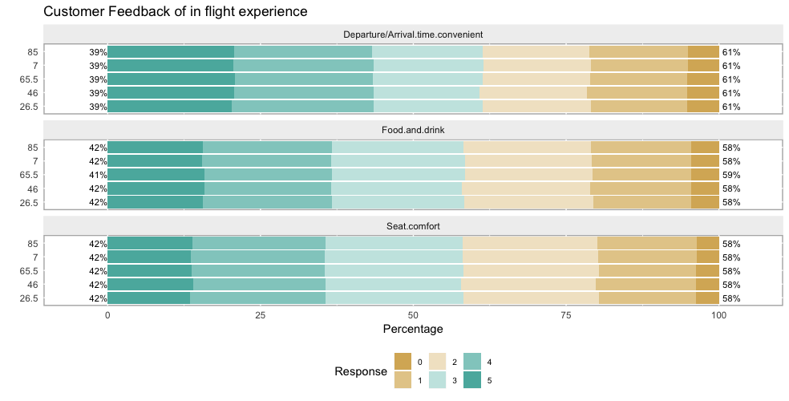

Customer In flight experience

> We call it out as average response and report positive.

But as we all know, >Average is one of the biggest enemy of analysts!!

In the below graph, the number of people who gave 5 stars for seat comfort is highest for people who travelled by business class! But we thought seat comfort was good irrespective of the class as per the above graph.

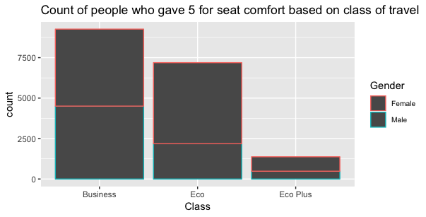

Customer In flight experience

This is where segmentation comes into picture.

> Segmentation:Segmentation is a process of breaking a group of entities (Parent group) into multiple groups of entities (Child group) so that entities in child group have higher homogeneity with in its entities.

Usally segmentation is used for deciding the right group to sell the product. However, it is also used in scenarios like above.

How to create a segmentation: -Step 1: Define the purpose of the segmentation. How do you want to use this segmentation? Is it for new customer acquisition? Managing a portfolio of existing customers? or Reducing credit exposure to reduce charge-offs? Every segmentation is created for a purpose. Until this purpose is clear, you will not be able to create a good segmentation.

-Step 2: Identify the most critical parameters (variables) which influence the purpose of the segmentation. List them in order of their importance. Now, there are multiple statistical techniques like Clustering, Decision tree which help you do this. If you don’t know these, use your business knowledge and understanding to come out with the list. For example, if you want to create a segmentation of products and focus on products which are most profitable, most critical parameters would be Cost and Revenue. If the problem is related to identifying best talent, the variables would be skill and motivation.

-Step 3: Once these variables are identified, you need to identify the granularity and threshold for creating segments. Again, these can come from the technique developed, but business knowledge could be deployed equally well. As a general guidance, you should have 2 – 3 levels for each important variable identified. However, it depends on complexity of problem, ability of your systems and openness of your business to adapt a segmentation. Some of the simple ways to decide threshold could be: 1. High / Medium / Low with numerical thresholds 2. 0 / 1 for binary output 3. Vintage / Age of customers

-Step 4: Assign customers to each of the cells and see if there is a fair distribution. If not, tweak the thresholds or variables. Perform step 2, 3 and 4 iteratively till you create a fair distribution.

-Step 5: Include this segmentation in your analysis and analyze at segment level (and not at macro level!)

Above steps taken from this link: https://www.analyticsvidhya.com/blog/2013/08/importance-segmentation-create/